# final project with comments

Alia Lancaster

Read in data and packages

```r
ax <- read.csv("ax_AL.csv")

library(ggplot2)
library(dplyr)
library(reshape2)
```

Goal: Calculate d-prime per subject, context (initial, medial, final), and pair (28 pairs of phonemes). Record the number of times the proportion of hits or misses is 0 or 1, then replace these special cases with values that represent a similar pattern of response but do not cause “Inf” or “Nan”. Create boxplots to examine the distribution of d-prime.

Step 1) Create a new column for each phoneme pair that takes into account the same and different pairs. For instance, the factor “phoneme_pair” includes “Ah”, “AA”, and “hh”. Create a column called “Ah” that records if a trial is any of those three pairs. A separate column is needed for each pair because the same pairs overlap. For instance, the same pairs for “Ah” and “Ax” both include “AA”. These new columns will be used in subsetting later on.

```r
# make all of the strings in 'phoneme_pair' equal to 2 characters.  Take out or replace "-"
summary(ax$phoneme_pair)
```

```
## A-A-  A-h A-h-  A-q  A-R  A-s  A-x  A-z h-h-  h-q  h-R  h-s  h-x  h-z   hh
## 1341  384  384  384  384  384  384  371 1335  512  446  382  384  544 1344
##  hh-   hq   hR   hs   hx   hz   qq   qR   qs   qx   qz   RR   Rs   Rx   Rz
##  384  256  318  384  384  182 1342  384  384  384  364 1342  381  379  361
##   ss   sx   sz   xx   xz   zz
## 1342  384  364 1344  364 1274
```

```r
ax$phoneme_pair <- factor(gsub("A-", "A", ax$phoneme_pair))
ax$phoneme_pair <- factor(gsub("h-", "H", ax$phoneme_pair))
summary(ax$phoneme_pair)
```

```
##   AA   Ah   AH   Aq   AR   As   Ax   Az   hh   hH   HH   hq   Hq   hR   HR
## 1341  384  384  384  384  384  384  371 1344  384 1335  256  512  318  446
##   hs   Hs   hx   Hx   hz   Hz   qq   qR   qs   qx   qz   RR   Rs   Rx   Rz
##  384  382  384  384  182  544 1342  384  384  384  364 1342  381  379  361
##   ss   sx   sz   xx   xz   zz
## 1342  384  364 1344  364 1274
```

```r
#split by nothing and rbind to ax
sst <- do.call(rbind, strsplit(as.character(ax$phoneme_pair), ""))
phoneme1 <- sst[,1]
phoneme2 <- sst[,2]
ax <- cbind(ax, phoneme1, phoneme2)
names(ax)
```

```
##  [1] "X"                    "Item"                 "SubjectID"
##  [4] "RT"                   "ACC"                  "spkr"
##  [7] "correct_response"     "confusable"           "word1"
## [10] "word2"                "gender_order"         "context"
## [13] "phoneme_pair_ordered" "phoneme_pair"         "pu"
## [16] "vvl"                  "list"                 "phoneme1"
## [19] "phoneme2"
```

```r
# Create a new column for each pair, collapsing across same and different trials
paircol <- vector(length=length(ax$phoneme_pair))
for(pair in levels(droplevels(ax[ax$correct_response==0, "phoneme_pair"]))){
    pair1 <- strsplit(as.character(pair), "")[[1]][1]
    pair2 <- strsplit(as.character(pair), "")[[1]][2]
    paircol <- factor(ifelse(ax$phoneme_pair==pair, pair, ifelse(ax$correct_response==1 &  ax$phoneme1==pair1, pair, ifelse(ax$correct_response==1 & ax$phoneme1 ==pair2, pair, 0))))
    ax<- cbind(ax, paircol)
    names(ax)[names(ax)=="paircol"] <- pair
  }
```

Step 2) Add 4 factors for hits, misses, false alarms, and correct responses.

```r
make.newcol <- function(data, x, x2){
  hits <- ifelse(data[,x]=="0" & data[,x2]==1,1,0)
  fa <- ifelse(data[,x]=="0" & data[,x2]==0,1,0)
  m <- ifelse(data[,x]=="1" & data[,x2]==0,1,0)
  cr <- ifelse(data[,x]=="1" & data[,x2]==1,1,0)
  data <- cbind(data, hits, fa, m, cr)
}
ax <- make.newcol(ax, "correct_response", "ACC")
summary(ax)
```

```
##        X              Item         SubjectID           RT
##  Min.   :    1   Min.   :101.0   Min.   :200.0   Min.   :  13.67
##  1st Qu.: 5317   1st Qu.:260.0   1st Qu.:207.0   1st Qu.: 823.23
##  Median :10632   Median :343.0   Median :215.0   Median : 989.16
##  Mean   :10632   Mean   :339.4   Mean   :226.8   Mean   :1044.82
##  3rd Qu.:15948   3rd Qu.:428.0   3rd Qu.:254.0   3rd Qu.:1211.27
##  Max.   :21264   Max.   :511.0   Max.   :262.0   Max.   :2000.62
##
##       ACC         spkr       correct_response confusable     word1
##  Min.   :0.0000   L2:13440   Min.   :0.0000   I :10664   4906   :  957
##  1st Qu.:1.0000   NS: 7824   1st Qu.:0.0000   N : 9069   4907   :  957
##  Median :1.0000              Median :1.0000   Y :  763   4905   :  950
##  Mean   :0.8588              Mean   :0.5015   Y2:  768   4504   :  896
##  3rd Qu.:1.0000              3rd Qu.:1.0000              4505   :  896
##  Max.   :1.0000              Max.   :1.0000              4605b  :  896
##                                                          (Other):15712
##      word2       gender_order context  phoneme_pair_ordered
##  4907   :  960   fm:10626     F:7475   hh     : 1344
##  4906   :  957   mf:10638     I:6638   xx     : 1344
##  4905   :  950                M:7151   qq     : 1342
##  4305   :  896                         RR     : 1342
##  4504   :  896                         ss     : 1342
##  4505   :  896                         A-A-   : 1341
##  (Other):15709                         (Other):13209
##   phoneme_pair   pu        vvl        list         phoneme1
##  hh     : 1344   0:15139   0 :15134   a:11280   A      :4016
##  xx     : 1344   p: 3060   v : 3067   b: 9984   H      :3603
##  qq     : 1342   u: 3065   vl: 3063             h      :3252
##  RR     : 1342                                  q      :2858
##  ss     : 1342                                  R      :2463
##  AA     : 1341                                  s      :2090
##  (Other):13209                                  (Other):2982
##     phoneme2     Ah         AH         Aq         AR         As
##  z      :3824   0 :18195   0 :18204   0 :18197   0 :18197   0 :18197
##  x      :3643   Ah: 3069   AH: 3060   Aq: 3067   AR: 3067   As: 3067
##  s      :3257
##  R      :2874
##  q      :2494
##  H      :2103
##  (Other):3069
```

[output cut: 25 more lines]

```
##  0 :18199   0 :18287   0 :18194   0 :18284   0 :18282   Min.   :0.0000
##  Rx: 3065   Rz: 2977   sx: 3070   sz: 2980   xz: 2982   1st Qu.:0.0000
##                                                         Median :0.0000
##                                                         Mean   :0.4274
##                                                         3rd Qu.:1.0000
##                                                         Max.   :1.0000
##
##        fa                m                 cr
##  Min.   :0.00000   Min.   :0.00000   Min.   :0.0000
##  1st Qu.:0.00000   1st Qu.:0.00000   1st Qu.:0.0000
##  Median :0.00000   Median :0.00000   Median :0.0000
##  Mean   :0.07106   Mean   :0.07017   Mean   :0.4313
##  3rd Qu.:0.00000   3rd Qu.:0.00000   3rd Qu.:1.0000
##  Max.   :1.00000   Max.   :1.00000   Max.   :1.0000
##
```

Step 3) Calculate number of proportion of hits and false alarms for each pair, subject, context. There are 28 pairs, 32 subjects, and three contexts, so there should be 896 rows per context

```r
# proportion function

prop <- function(vector1, vector2){
  numer <- sum(vector1)
  denom <- sum(vector1) + sum(vector2)
  output <- numer/denom
  output
}
# for loop
dprime.all <- data.frame()
this.subset <- data.frame()
for(column in colnames(ax[, c(20:47)])){
  this.subset <- ax[ax[,column] == column, c("Item", "SubjectID", "context", "correct_response","RT", "ACC", "spkr", "pu", "vvl", "list", "hits", "fa", "m", "cr") ]
  this.subset <- droplevels(this.subset)
  this.sum <- this.subset %>%
    group_by(SubjectID, context, spkr) %>%
    summarize(pH = prop(hits, m), pFA = prop(fa, cr), pair = column, meanRT = mean(RT), meanACC= mean(ACC))
  dprime.all <- rbind(dprime.all, this.sum)
}

summary(dprime.all)
```

```
##    SubjectID     context spkr            pH              pFA
##  Min.   :200.0   F:896   L2:1680   Min.   :0.0000   Min.   :0.00000
##  1st Qu.:207.8   I:896   NS:1008   1st Qu.:0.3333   1st Qu.:0.00000
##  Median :215.5   M:896             Median :0.5000   Median :0.00000
##  Mean   :227.1                     Mean   :0.5300   Mean   :0.02209
##  3rd Qu.:254.2                     3rd Qu.:0.6667   3rd Qu.:0.03846
##  Max.   :262.0                     Max.   :1.0000   Max.   :0.17391
##                                    NA's   :25       NA's   :1
##      pair               meanRT          meanACC
##  Length:2688        Min.   : 618.3   Min.   :0.0000
##  Class :character   1st Qu.: 931.4   1st Qu.:0.8056
##  Mode  :character   Median :1022.4   Median :0.8824
##                     Mean   :1045.5   Mean   :0.8596
##                     3rd Qu.:1159.8   3rd Qu.:0.9375
##                     Max.   :1483.3   Max.   :1.0000
##
```

```r
length(dprime.all$context)
```

```
## [1] 2688
```

```r
#the rbind made some factors into characters, so change them back to factors
dprime.all$pair <- as.factor(dprime.all$pair)
dprime.all$pair <- as.factor(dprime.all$pair)

## add the pu and vvl factors back
dprime.all$pu <- as.factor(ifelse(dprime.all$pair=="AH", "p", ifelse(dprime.all$pair=="Rx", "u", "c")))
summary(dprime.all)
```

```
##    SubjectID     context spkr            pH              pFA
##  Min.   :200.0   F:896   L2:1680   Min.   :0.0000   Min.   :0.00000
##  1st Qu.:207.8   I:896   NS:1008   1st Qu.:0.3333   1st Qu.:0.00000
##  Median :215.5   M:896             Median :0.5000   Median :0.00000
##  Mean   :227.1                     Mean   :0.5300   Mean   :0.02209
##  3rd Qu.:254.2                     3rd Qu.:0.6667   3rd Qu.:0.03846
##  Max.   :262.0                     Max.   :1.0000   Max.   :0.17391
##                                    NA's   :25       NA's   :1
##       pair          meanRT          meanACC       pu
##  Ah     :  96   Min.   : 618.3   Min.   :0.0000   c:2496
##  AH     :  96   1st Qu.: 931.4   1st Qu.:0.8056   p:  96
##  Aq     :  96   Median :1022.4   Median :0.8824   u:  96
##  AR     :  96   Mean   :1045.5   Mean   :0.8596
##  As     :  96   3rd Qu.:1159.8   3rd Qu.:0.9375
##  Ax     :  96   Max.   :1483.3   Max.   :1.0000
##  (Other):2112
```

```r
dprime.all$vvl <- as.factor(ifelse(dprime.all$pair=="AR", "v", ifelse(dprime.all$pair=="Hx", "vl", "c")))
summary(dprime.all)
```

```
##    SubjectID     context spkr            pH              pFA
##  Min.   :200.0   F:896   L2:1680   Min.   :0.0000   Min.   :0.00000
##  1st Qu.:207.8   I:896   NS:1008   1st Qu.:0.3333   1st Qu.:0.00000
##  Median :215.5   M:896             Median :0.5000   Median :0.00000
##  Mean   :227.1                     Mean   :0.5300   Mean   :0.02209
##  3rd Qu.:254.2                     3rd Qu.:0.6667   3rd Qu.:0.03846
##  Max.   :262.0                     Max.   :1.0000   Max.   :0.17391
##                                    NA's   :25       NA's   :1
##       pair          meanRT          meanACC       pu       vvl
##  Ah     :  96   Min.   : 618.3   Min.   :0.0000   c:2496   c :2496
##  AH     :  96   1st Qu.: 931.4   1st Qu.:0.8056   p:  96   v :  96
##  Aq     :  96   Median :1022.4   Median :0.8824   u:  96   vl:  96
##  AR     :  96   Mean   :1045.5   Mean   :0.8596
##  As     :  96   3rd Qu.:1159.8   3rd Qu.:0.9375
##  Ax     :  96   Max.   :1483.3   Max.   :1.0000
##  (Other):2112
```

Step 4) Make tables of frequency of special cases. The if/else loop in the function exists because pFA does not have any instances of 1, which makes the number of columns different in “final.df”.

```r
freq.tables <- function(data, groupvar, numvar){
  groupvar.sum<- xtabs(~data[, groupvar] + data[,numvar], data=data)
  groupvar.sum <- as.data.frame(groupvar.sum)
  groupvar.sum <- groupvar.sum[groupvar.sum[,2]==0 | groupvar.sum[, 2]==1, ]
  groupvar.cast <- dcast(groupvar.sum, groupvar.sum[,1] ~ groupvar.sum[,2], value.var="Freq")
  total <- xtabs(~data[, groupvar], data=data)
  total <- as.data.frame(total)
  final.df <- cbind(groupvar.cast, total[, 2])
  if ((length(names(final.df))) > 3){
  final.df$Perc0 <- round((final.df[, "0"]/final.df[,4])*100, digits=3)
  final.df$Perc1 <- round((final.df[, "1"]/final.df[,4])*100, digits=3)
  final.df$TotalPerc <- final.df$Perc0 + final.df$Perc1
  output <- final.df
  } else
  final.df$Perc0 <- round((final.df[, "0"]/final.df[,3])*100, digits=3)
  output <- final.df
}

pair.pH <-freq.tables(dprime.all, "pair", "pH")
subject.pH <- freq.tables(dprime.all, "SubjectID", "pH")
subject.pFA <- freq.tables(dprime.all, "SubjectID", "pFA")
pair.pFA <- freq.tables(dprime.all, "pair", "pFA")

pair.pH
```

```
##    groupvar.sum[, 1]  0  1 total[, 2]  Perc0  Perc1 TotalPerc
## 1                 Ah  1 21         96  1.042 21.875    22.917
## 2                 AH  0 19         96  0.000 19.792    19.792
## 3                 Aq  0 10         96  0.000 10.417    10.417
## 4                 AR  0 12         96  0.000 12.500    12.500
## 5                 As  0 23         96  0.000 23.958    23.958
## 6                 Ax  0 18         96  0.000 18.750    18.750
## 7                 Az  3  0         96  3.125  0.000     3.125
## 8                 hH 36 13         96 37.500 13.542    51.042
## 9                 hq  1  6         96  1.042  6.250     7.292
## 10                Hq  0  8         96  0.000  8.333     8.333
## 11                hR  5  7         96  5.208  7.292    12.500
## 12                HR  0 10         96  0.000 10.417    10.417
## 13                hs  0 19         96  0.000 19.792    19.792
## 14                Hs  0 23         96  0.000 23.958    23.958
## 15                hx  3 17         96  3.125 17.708    20.833
## 16                Hx  5 18         96  5.208 18.750    23.958
## 17                hz  5  0         96  5.208  0.000     5.208
## 18                Hz  3  0         96  3.125  0.000     3.125
## 19                qR  0  4         96  0.000  4.167     4.167
## 20                qs  0 11         96  0.000 11.458    11.458
## 21                qx  0  8         96  0.000  8.333     8.333
## 22                qz  5  0         96  5.208  0.000     5.208
## 23                Rs  0 12         96  0.000 12.500    12.500
## 24                Rx 13 11         96 13.542 11.458    25.000
## 25                Rz  2  0         96  2.083  0.000     2.083
## 26                sx  0 20         96  0.000 20.833    20.833
## 27                sz  4  0         96  4.167  0.000     4.167
## 28                xz  1  0         96  1.042  0.000     1.042
```

```r
subject.pH
```

```
##    groupvar.sum[, 1] 0  1 total[, 2] Perc0  Perc1 TotalPerc
## 1                200 3 21         84 3.571 25.000    28.571
## 2                201 4  1         84 4.762  1.190     5.952
## 3                202 1 20         84 1.190 23.810    25.000
## 4                203 4  0         84 4.762  0.000     4.762
## 5                204 8  3         84 9.524  3.571    13.095
## 6                205 3  0         84 3.571  0.000     3.571
## 7                206 2  0         84 2.381  0.000     2.381
## 8                207 5  3         84 5.952  3.571     9.523
## 9                208 1  2         84 1.190  2.381     3.571
## 10               209 3  0         84 3.571  0.000     3.571
## 11               210 2 14         84 2.381 16.667    19.048
## 12               211 0  6         84 0.000  7.143     7.143
## 13               212 2  3         84 2.381  3.571     5.952
## 14               213 4  1         84 4.762  1.190     5.952
```

[output cut: 18 more lines]

```r
subject.pFA
```

```
##    groupvar.sum[, 1]  0 total[, 2]  Perc0
## 1                200 57         84 67.857
## 2                201 38         84 45.238
## 3                202 63         84 75.000
## 4                203 50         84 59.524
## 5                204 28         84 33.333
## 6                205 55         84 65.476
## 7                206 45         84 53.571
## 8                207 45         84 53.571
## 9                208 61         84 72.619
## 10               209 44         84 52.381
## 11               210 65         84 77.381
## 12               211 61         84 72.619
## 13               212 66         84 78.571
## 14               213 40         84 47.619
```

[output cut: 18 more lines]

```r
pair.pFA
```

```
##    groupvar.sum[, 1]  0 total[, 2]  Perc0
## 1                 Ah 57         96 59.375
## 2                 AH 47         96 48.958
## 3                 Aq 79         96 82.292
## 4                 AR 62         96 64.583
## 5                 As 81         96 84.375
## 6                 Ax 66         96 68.750
## 7                 Az  2         96  2.083
## 8                 hH 17         96 17.708
## 9                 hq 81         96 84.375
## 10                Hq 76         96 79.167
## 11                hR 58         96 60.417
## 12                HR 47         96 48.958
## 13                hs 74         96 77.083
## 14                Hs 85         96 88.542
## 15                hx 46         96 47.917
## 16                Hx 51         96 53.125
## 17                hz 91         96 94.792
## 18                Hz 77         96 80.208
## 19                qR 65         96 67.708
## 20                qs 85         96 88.542
## 21                qx 70         96 72.917
## 22                qz 75         96 78.125
## 23                Rs 79         96 82.292
## 24                Rx 33         96 34.375
## 25                Rz 80         96 83.333
## 26                sx 74         96 77.083
## 27                sz 60         96 62.500
## 28                xz 86         96 89.583
```

Step 5) Deal with special cases, then add d-prime. Replacements: - hits: 4 trials, so 4/4 is the most possible hits and 0/4 is the least possible hits. The next higherst number of hits is 3/4 = .75, and the next lowest number of hits is 1/4 = .25. Replace 1 with the value halfway between 1 and .75, which is .875. Replace 0 with the value halfway between 0 and .25, which is 0.125 - false alarms: 32 trials. The next highest number of false alarms is 31/33 = 0.96875, and the next lowest number of false alarms is 1/32 = 0.03125. Replace 1 with the value halfway between 1 and .96875, which is 0.984375. Replace 0 with the value halfway between 0 and 0.03125, which is 0.015625.

```r
# the max number of different trials a person heard of a certain pair in a certain context
maxh = 4

# the max number of same trials a person heard of a certain pair in a certain context
maxfa = 32

dprime <- function(data, pH, pFA){
  data[, pH] <- ifelse(data[, pH]==1, (1-(1-((maxh-1)/maxh))/2), ifelse(data[, pH]==0, ((1/maxh)/2), data[, pH]))
  data[, pFA] <- ifelse(data[, pFA]==1, (1-(1-((maxfa-1)/maxfa))/2), ifelse(data[, pFA]==0, ((1/maxfa)/2), data[, pFA]))
  output <- qnorm(data[,pH]) - qnorm(data[,pFA])
  output
}


dprime.all$dprime <- dprime(dprime.all, "pH", "pFA")
summary(dprime.all)
```

```
##    SubjectID     context spkr            pH              pFA
##  Min.   :200.0   F:896   L2:1680   Min.   :0.0000   Min.   :0.00000
##  1st Qu.:207.8   I:896   NS:1008   1st Qu.:0.3333   1st Qu.:0.00000
##  Median :215.5   M:896             Median :0.5000   Median :0.00000
##  Mean   :227.1                     Mean   :0.5300   Mean   :0.02209
##  3rd Qu.:254.2                     3rd Qu.:0.6667   3rd Qu.:0.03846
##  Max.   :262.0                     Max.   :1.0000   Max.   :0.17391
##                                    NA's   :25       NA's   :1
##       pair          meanRT          meanACC       pu       vvl
##  Ah     :  96   Min.   : 618.3   Min.   :0.0000   c:2496   c :2496
##  AH     :  96   1st Qu.: 931.4   1st Qu.:0.8056   p:  96   v :  96
##  Aq     :  96   Median :1022.4   Median :0.8824   u:  96   vl:  96
##  AR     :  96   Mean   :1045.5   Mean   :0.8596
##  As     :  96   3rd Qu.:1159.8   3rd Qu.:0.9375
##  Ax     :  96   Max.   :1483.3   Max.   :1.0000
##  (Other):2112
##      dprime
##  Min.   :-0.4229
##  1st Qu.: 1.5011
##  Median : 2.1539
##  Mean   : 2.0201
##  3rd Qu.: 2.5846
##  Max.   : 3.3042
##  NA's   :26
```

Step 6) Use boxplots to view distribution of d-prime across contexts and by speaker

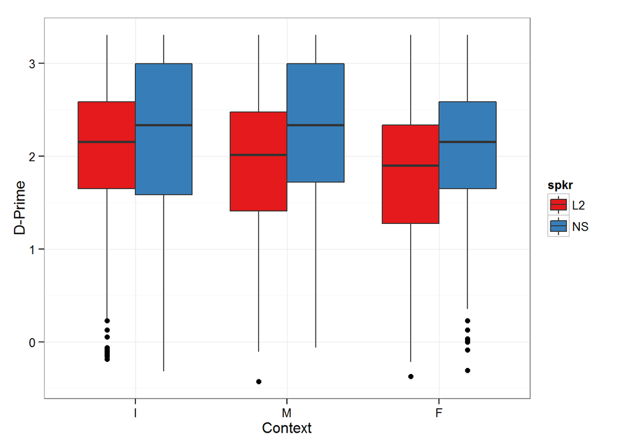

```r
#get rid of NAs for boxplots
dprime.all.noNA <- dprime.all[!is.na(dprime.all$dprime),]
#reorder context to initial, medial, final
dprime.all.noNA$context <- factor(dprime.all.noNA$context, levels = c("I", "M", "F"))


# dprime by speaker and context
ggplot(dprime.all.noNA, aes(x=context, y=dprime, fill = spkr)) + geom_boxplot() + scale_fill_brewer(palette="Set1") + xlab("Context") + ylab("D-Prime") + theme_bw()
```

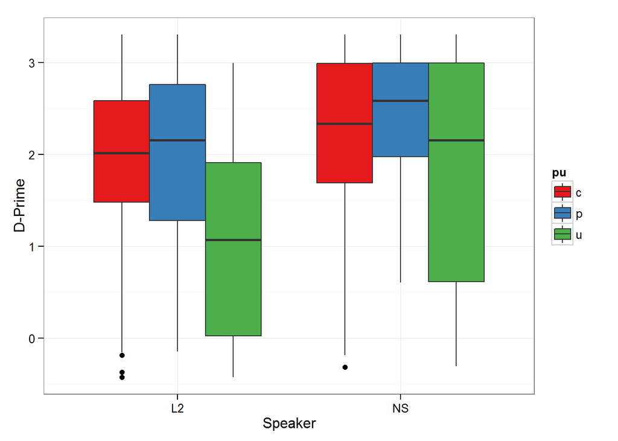

```r
# dprime by speaker and manner type (pharyngeal, uvular, control)
ggplot(dprime.all.noNA, aes(x=spkr, y=dprime, fill = pu)) + geom_boxplot() + scale_fill_brewer(palette="Set1") + xlab("Speaker") + ylab("D-Prime") + theme_bw()
```

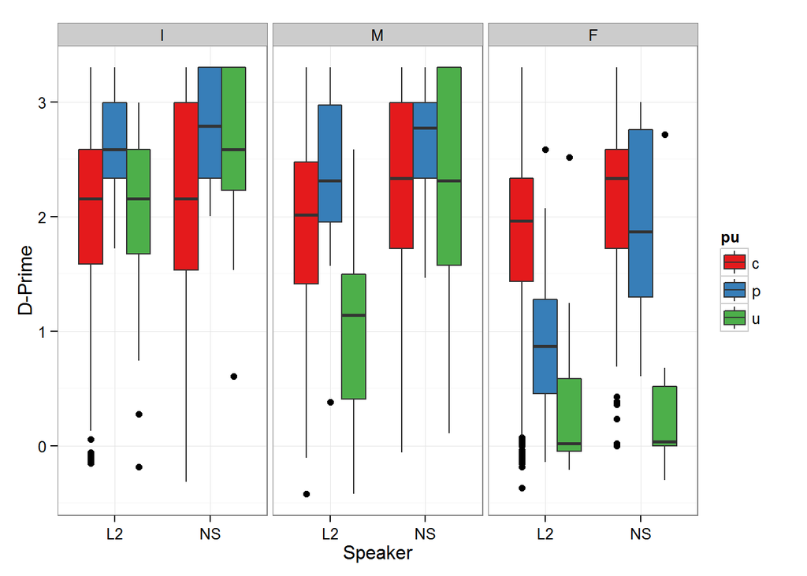

```r
# dprime by speaker, context, and manner type (pharyngeal, uvular, control)
ggplot(dprime.all.noNA, aes(x=spkr, y=dprime, fill = pu)) + geom_boxplot() + scale_fill_brewer(palette="Set1") + xlab("Speaker") + ylab("D-Prime") + theme_bw() + facet_grid (.~context)
```

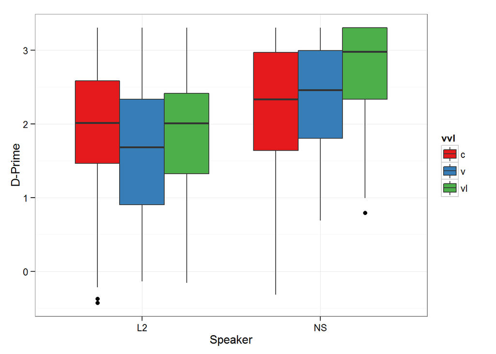

```r
# dprime by speaker and voicing type (voiced, voiceless, control)
ggplot(dprime.all.noNA, aes(x=spkr, y=dprime, fill = vvl)) + geom_boxplot() + scale_fill_brewer(palette="Set1") + xlab("Speaker") + ylab("D-Prime") + theme_bw()
```

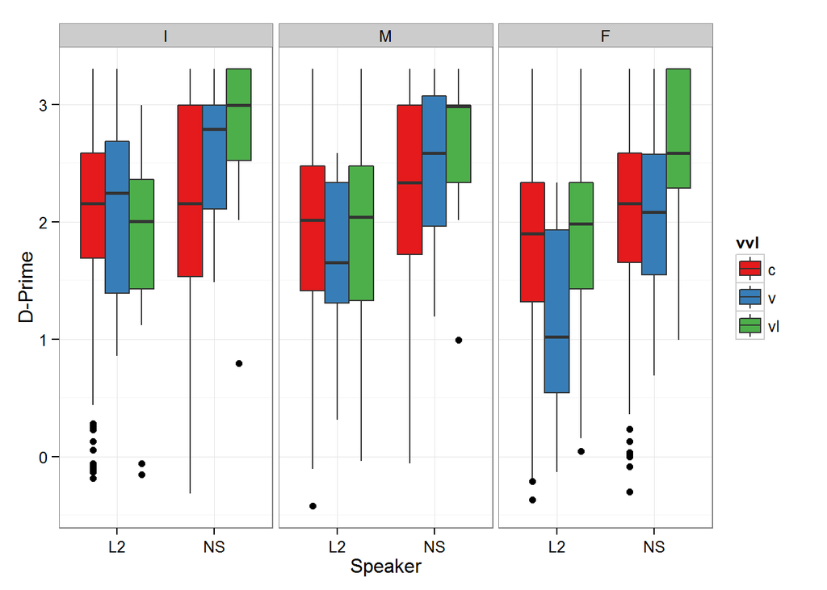

```r
#dprime by speaker, context, and voicing type (voiced, voiceless, control)
ggplot(dprime.all.noNA, aes(x=spkr, y=dprime, fill = vvl)) + geom_boxplot() + scale_fill_brewer(palette="Set1") + xlab("Speaker") + ylab("D-Prime") + theme_bw() + facet_grid (.~context)
```